# **【Read Bible】**

Daily Living Water

2023 August

# **August 7**, Isaiah 3:1-12

- [Read together](https://www.youtube.com/watch?v=pTJoBlYENrI)

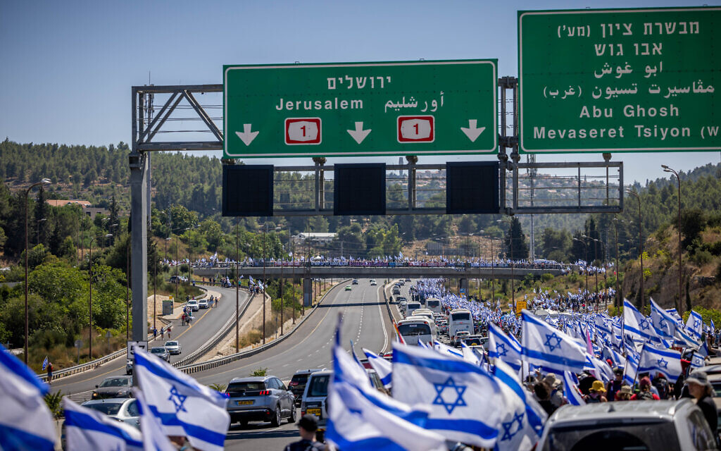

[image from](https://theworldnews.net/il-news/protesters-reach-jerusalem-outskirts-begin-last-leg-of-march-to-knesset)

#### `Jerusalem of Its Last Legs`

**`1-7` The Master, God-of-the-Angel-Armies, is emptying Jerusalem and Judah of all the basic necessities, plain bread and water to begin with. He’s withdrawing police and protection, judges and courts, pastors and teachers, captains and generals, doctors and nurses, and, yes, even the repairmen and jacks-of-all-trades. He says, “I’ll put little kids in charge of the city. Schoolboys and schoolgirls will order everyone around. People will be at each other’s throats, stabbing one another in the back: Neighbor against neighbor, young against old, the no-account against the well-respected. One brother will grab another and say, ‘You look like you’ve got a head on your shoulders. Do something! Get us out of this mess.’ And he’ll say, ‘Me? Not me! I don’t have a clue. Don’t put me in charge of anything.’**

**`8-9` “Jerusalem’s on its last legs. Judah is soon down for the count. Everything people say and do is at cross-purposes with GOD, a slap in my face. Brazen in their depravity, they flaunt their sins like degenerate Sodom. Doom to their eternal souls! They’ve made their bed; now they’ll sleep in it.**

**`10-11` “Reassure the righteous that their good living will pay off. But doom to wicked! Disaster! Everything you did will be done to them.**

**`12` “Skinny kids terrorize my people. Silly girls bully them around. My dear people! Your leaders are talking you down a blind alley. They’re sending you off on a wild-goose chase.”**

#### **Vocabularies**

`depravity`

`eternal`

`cross-purposes`

`at cross-purposes with`